# Model Extension

Kirisanth

Tuesday, November 18, 2014

# How hunting affects polar bear population

Worked with Sujitha Nitheyanantharajah for initial analysis  
**Initial Model** White-tailed deer and Plant Model  
Predator-prey model  
Can be applied to model polar bears and seal interaction  
Plants  
$P(t + 1) = P(t) + aP(t) - cP(t)D(t)$ Deers  
$D(t + 1) = D(t) + ecP(t)D(t) - fD(t) - h$ where:  
$a$ is the growth rate of plants in the absence of deer  
$c$ is the per-deer-plant-encounter rate  
$e$ is the efficiency of deer at converting captured plants into resources  
$f$ is the per-deer mortality rate  
$h$ is the permitted hunting rate

Solve for fixed points  
$P{\star} = P{\star}(1 + a - cD{\star})$  
$D{\star} = D{\star}(1 + ecP{\star} - f - h)$  
Fixed Points:  
$(0, 0)$  
$((-1+f+h)/ec, (1+a)/c)$

A fixed point is stable if all of the eigenvalues of this matrix (evaluating at the fixed point) have absolute value less than one.  
The Jacobian for the predator-prey model is  
$\begin{equation*} \label{eq:1} \begin{pmatrix} \frac{\partial D(t+1)}{\partial D(t)} & \frac{\partial D(t+1)}{\partial P(t)} \\ \frac{\partial P(t+1)}{\partial D(t)} & \frac{\partial P(t+1)}{\partial P(t)} \\ \end{pmatrix} \end{equation*}$

Jacobian for above equations  
$\begin{equation*} \label{eq:2} \begin{pmatrix} 1 + a - cD & -cP \\ ecD & ecP - f \\ \end{pmatrix} \end{equation*}$

For $(0, 0)$  
$\begin{equation*} \label{eq:3} \begin{pmatrix} 1 + a & 0 \\ 0 & - f \\ \end{pmatrix} \end{equation*}$

For $((-1+f+h)/ec, (1+a)/c)$  
$\begin{equation*} \label{eq:4} \begin{pmatrix} 1 + a - c((1+a)/c) & -c((-1+f+h)/ec) \\ ec((1+a)/c) & ec((-1+f+h)/ec) - f \\ \end{pmatrix} \end{equation*}$

$\begin{equation*} \label{eq:5} \begin{pmatrix} 0 & (1-f-h)/e \\ e(1+a) & (h-1) \\ \end{pmatrix} \end{equation*}$

```r
P <- 1:50
P[1] <- 100
D <- 1:50
D[1] <- 1

a <- 2 #Plant growth rate without deer.
c <- 0.5 #Plant deer encounter rate
e <- 0.3 #efficiency for deer to convert plant to deer
f <- 0.6 #mortality rate deer
h <- 0 #hunting rate deer

for (i in 1:49) {
  #prevents negative numbers from occuring
  if (P[i] < 0) {
    P[i] <- 0
  }
  if (D[i] < 0) {
    D[i] <- 0
  }

  P[i+1] <- P[i] + a*P[i] - c*P[i]*D[i]
  D[i+1] <- D[i] + e*c*P[i]*D[i] - f*D[i] - h
}
```

Plots:

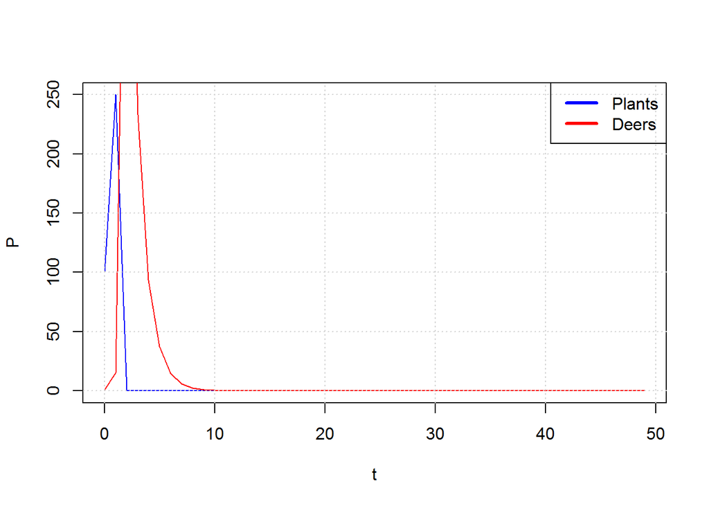

# Polar bear population, with Seals and human hunting activity

Predator-prey model extended to include other factors

## Preliminary question

Polar bears once abundant in the artic circle are now facing extinction. They are found in Canada, Greenland, Russia, and Alaska. Polar bears are an apex predator. One of their primary food source is the ring tail seal. If hunting of seals and polar bears were to increase it could hurt polar bear populations. Here we will model polar bear populations with seal populations with hunting in the arctic. What should hunting levels of seals and polar bears be kept at to keep polar bear populations stable.

Here we start by adding a conservation migration rate which is a constant. So the seal population has a growth rate, but we make the assumption that any time a polar bear sees a seal the seal would be killed. For the polar bears we have a growth rate which depends on the number of seals killed and a mortality rate subtracting from the population.

Since our model is considered non linear discrete time we can find stability by either finding out all eigenvalues and seeing if it is less than one. Or for the case if you get a 2 by 2 Jacobian matrix then you can find stability with $|\tau| < \delta + 1$ for the jacobian.

**Seal population** $S(t + 1) = S(t) + r_{g}S(t) - c_{ps}S(t)P(t) + m_{S}$ **Polar bear population** $P(t + 1) = P(t) + e_{ps}c_{ps}S(t)P(t) - d_{p}P(t)$

**Constants**:  
$r_{g}$ is the growth rate of seals in the absence of polar bears  
$c_{ps}$ is the per-polar bear-seal-encounter rate  
$e_{ps}$ is the efficiency of deer at converting captured plants into resources  
$d_{p}$ is the per-polar bear mortality rate  
$m_{S}$ is the per-polar bear migration rate

```r
#Polar bears vs seals
S <- 1:50 #Seal population
P <- 1:50 #Polar bear population

S[1] = 60 #Initial Seal population
P[1] = 20 #Initial polar bear population

rg <- 0.5 #Seal growth rate without polar bear or humans.
cps <- 0.01 #seal-polar bear encounter rate

eps <- 0.1 #polar bear efficiency to convert one seal to another polar bear
dp <- 0.1 #polar bear mortality rate

ms <- 0.5 #seal migration rate from conservation

for (t in 1:49) {
  if (S[t] < 0) {
    S[t] <- 0
  }
  if (P[t] < 0) {
    P[t] <- 0
  }
  #Seal population
  S[t + 1] <- S[t] + rg*S[t] - cps*S[t]*P[t] + ms
  #Polar bear population
  P[t + 1] <- P[t] + eps*cps*S[t]*P[t] - dp*P[t]
}
```

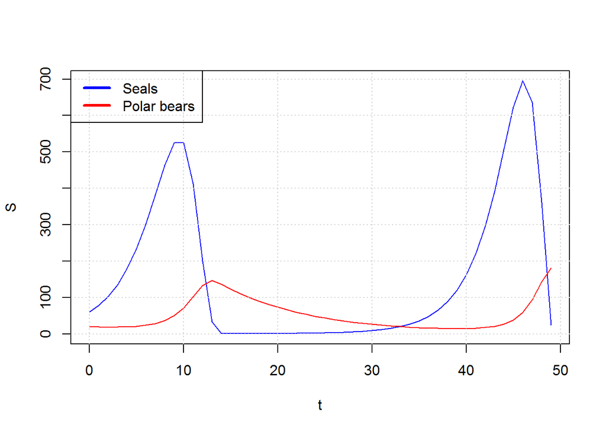

Seal population $S(t + 1) = S(t) + r_{g}S(t) - c_{ps}S(t)P(t) + m_{S}C_{S}(t)$ Polar bear population $P(t + 1) = P(t) + e_{ps}c_{ps}S(t)P(t) - d_{p}P(t)$ Seal Conservation $C_{S}(t+1) = C_{S}(t) + r_{S}C_{S}(t)(1 - C_{S}(t)/K_{SC}) - m_{S}C_{S}(t)$

New Constants:  
$r_{s}$ is the growth rate of seals in the conservation  
$K_{SC}$ capacity of conservation

Solve for fixed points  
$S{\star} = S{\star} + r_{g}S{\star} - c_{ps}S{\star}P + m_{S}C_{S}(t)$  
$P{\star} = P{\star} + e_{ps}c_{ps}SP{\star} - d_{p}P{\star})$  
$C_{S}{\star} = C_{S}{\star} + r_{S}C_{S}{\star}(1 - C_{S}{\star}/K_{SC}) - m_{S}C_{S}{\star}$

Isolate for $C{\star}$  
Since it is a one dimensional equation it can be considered as a constant  
$0 = r_{S}C_{S}{\star}(1 - C_{S}{\star}/K_{SC}) - m_{S}C_{S}{\star}$  
$0 = C_{S}{\star}(r_{S} - r_{S}C_{S}{\star}/K_{SC} - m_{S})$  
$0 = r_{S} - r_{S}C_{S}{\star}/K_{SC} - m_{S}$  
$C_{S}{\star} = (r_{S} - m_{S}) * K_{SC} / r_{S}$  
$C_{S}{\star} = (1 - m_{S}/r_{S}) * K_{SC}$ (constant)  
$S(t+1) = S(t) + r_{g}S(t) - c_{ps}S(t)P + m_{S}((1 - m_{S}/r_{S}) * K_{SC})$  
$P(t+1) = P(t) + e_{ps}c_{ps}SP(t) - d_{p}P(t))$  
Fixed Points:  
$(0, 0)$  
$S{\star} = d_{p}/(e_{ps}c_{ps})$  
$P{\star} = r_{g}/c_{ps} + ((e_{ps}m_{S}K_{SC})/d_{p})(1-m_{S}/r_{S})$  
For Fixed Points, $(\frac{d_{p}}{e_{ps}c_{ps}},\frac{r_{g}}{c_{ps}} + \frac{e_{ps}m_{S}K_{SC}}{d_{p}} (1-\frac{m_{S}}{r_{S}}))$

$\begin{equation*} \label{eq:8} \begin{pmatrix} 1 + r_{g} - c_{ps}[\frac{r_{g}}{c_{ps}} + \frac{e_{ps}m_{S}K_{SC}}{d_{p}} (1-\frac{m_{S}}{r_{S}})] & -c_{ps}\frac{d_{p}}{e_{ps}c_{ps}} \\ e_{ps}c_{ps}[\frac{r_{g}}{c_{ps}} + \frac{e_{ps}m_{S}K_{SC}}{d_{p}} (1-\frac{m_{S}}{r_{S}})] & 1+e_{ps}c_{ps}\frac{d_{p}}{e_{ps}c_{ps}} - d_{p} \\ \end{pmatrix} \end{equation*}$

$\begin{equation*} \label{eq:9} \begin{pmatrix} 1 - \frac{e_{ps}c_{ps}m_{S}K_{SC}}{d_{p}}(1-\frac{m_{S}}{r_{S}}) & -\frac{d_{p}}{e_{ps}} \\ e_{ps}r_{g} + \frac{e_{ps}^2c_{ps}m_{S}K_{SC}}{d_{p}} (1-\frac{m_{S}}{r_{S}}) & 1 \\ \end{pmatrix} \end{equation*}$

$|\tau| < \delta + 1$ $|1-\frac{e_{ps}c_{ps}m_{S}K_{SC}}{d_{p}}(1-\frac{m_{S}}{r_{S}})+1| < (1-\frac{e_{ps}c_{ps}m_{S}K_{SC}}{d_{p}}(1-\frac{m_{S}}{r_{S}})) + \frac{d_{p}}{e_{ps}} (e_{ps}(r_{S}+\frac{e_{ps}c_{ps}m_{S}K_{SC}}{d_{p}}(1-\frac{m_{S}}{r_{S}}))) +1$  
$\therefore$ stable if condition above is met

```r
S <- 1:50 #Seal population
P <- 1:50 #Polar bear population
CS <- 1:50 #Seal conservation population

S[1] = 40 #Initial Seal population
P[1] = 5 #Initial polar bear population
CS[1] = 2 #Initial seal conservation population

#Equation 1 seal population
rg <- 0.5 #Seal growth rate without polar bear or humans.
cps <- 0.1 #seal-polar bear encounter rate

#Equation 2 polar bear population
eps <- 0.2 #polar bear efficiency to convert one seal to another polar bear
dp <- 0.1 #polar bear mortality rate

#Equation 4
KSC <- 80 #Capacity
rs <- 0.5 #seal growth rate in conservation area
ms <- 0.2 #seal migration out rate

for (t in 1:49) {

  if (S[t] < 0) {
    S[t] <- 0
  }

  if (P[t] < 0) {
    P[t] <- 0
  }
  #Seal population
  S[t + 1] <- S[t] + rg*S[t] - cps*S[t]*P[t] + ms*CS[t]
  #Polar bear population
  P[t + 1] <- P[t] + eps*cps*S[t]*P[t] - dp*P[t]
  #Seal Conservation
  CS[t+1] <- CS[t] + rs*CS[t]*(1 - CS[t]/KSC) - ms*CS[t]  #1 dimensional
}
```

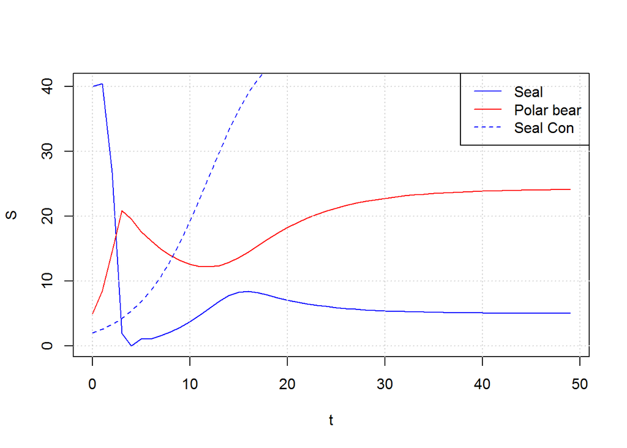

**Extending previous model with human hunting activity**  
Seal population $S(t + 1) = S(t) + r_{g}S(t) - c_{ps}S(t)P(t) - c_{hs}*S(t)*H(t) + m_{S}C_{S}(t)$ Polar bear population $P(t + 1) = P(t) + e_{ps}c_{ps}S(t)P(t) - d_{p}P(t) - c{hp}*P(t)*H(t)$ Human population $H(t+1) = H(t) + e_{hs}*c_{hs}*S(t)*H(t) + e_{hp}*c_{hp}*P(t)*H(t) - d_{h}*H(t)$ Seal Conservation $C_{S}(t+1) = C_{S}(t) + r_{S}C_{S}(t)(1 - C_{S}(t)/K_{SC}) - m_{S}C_{S}(t)$

new constants:  
$c_{hs}$ is the per-human-seal-encounter rate  
$e_{hs}$ is the efficiency of humans at converting hunted seals into another human  
$c_{hp}$ is the per-human-polar bear-encounter rate  
$e_{hp}$ is the efficiency of humans at converting hunted polar bears into another human  
$d_{h}$ is the per-human mortality rate

Solve for fixed points  
$S{\star} = S{\star} + r_{g}S{\star} - c_{ps}S{\star}P + m_{S}C_{S}(t)$  
$P{\star} = P{\star} + e_{ps}c_{ps}SP{\star} - d_{p}P{\star})$  
$H{\star} = H{\star} + e_{hs}*c_{hs}*S(t)*H{\star} + e_{hp}*c_{hp}*P(t)*H{\star} - d_{h}*H{\star}$  
$C_{S}{\star} = C_{S}{\star} + r_{S}C_{S}{\star}(1 - C_{S}{\star}/K_{SC}) - m_{S}C_{S}{\star}$

Isolate for $C{\star}$  
Since it is a one dimensional equation it can be considered as a constant  
$0 = r_{S}C_{S}{\star}(1 - C_{S}{\star}/K_{SC}) - m_{S}C_{S}{\star}$  
$0 = C_{S}{\star}(r_{S} - r_{S}C_{S}{\star}/K_{SC} - m_{S})$  
$0 = r_{S} - r_{S}C_{S}{\star}/K_{SC} - m_{S}$  
$C_{S}{\star} = (r_{S} - m_{S}) * K_{SC} / r_{S}$  
$C_{S}{\star} = (1 - m_{S}/r_{S}) * K_{SC}$ (constant)  
$S{\star} = S{\star} + r_{g}S{\star} - c_{ps}S{\star}P{\star} + m_{S}((1 - m_{S}/r_{S}) * K_{SC})$ $P{\star} = P{\star} + e_{ps}c_{ps}S{\star}P{\star} - d_{p}P{\star})$ $H{\star} = H{\star} + e_{hs}*c_{hs}*S{\star}*H{\star} + e_{hp}*c_{hp}*P{\star}*H{\star} - d_{h}*H{\star}$

**Fixed points**

$\begin{equation*} \label{eq:15} \begin{pmatrix} \frac{\partial P(t+1)}{\partial P(t)} & \frac{\partial P(t+1)}{\partial S(t)} & \frac{\partial P(t+1)}{\partial H(t)}\\ \frac{\partial S(t+1)}{\partial P(t)} & \frac{\partial S(t+1)}{\partial S(t)} & \frac{\partial S(t+1)}{\partial H(t)}\\ \frac{\partial I(t+1)}{\partial P(t)} & \frac{\partial I(t+1)}{\partial S(t)} & \frac{\partial I(t+1)}{\partial H(t)}\\ \end{pmatrix} \end{equation*}$

```r
S <- 1:50 #Seal population
P <- 1:50 #Polar bear population
H <- 1:50 #Human population
CS <- 1:50 #Seal conservation population

S[1] = 40 #Initial Seal population
P[1] = 5 #Initial polar bear population
H[1] = 5 #Initial human population
CS[1] = 2 #Initial seal conservation population

#Equation 1 seal population
rg <- 0.5 #Seal growth rate without polar bear or humans.
cps <- 0.1 #seal-polar bear encounter rate

#Equation 2 polar bear population
eps <- 0.2 #polar bear efficiency to convert one seal to another polar bear
dp <- 0.1 #polar bear mortality rate

#Equation 3 human population
ehs <- 0.2 #human efficiency to convert seals to human
ehp <- 0.02 #human efficiency to convert polar bears to human
chs <- 0.01 #seal human encounter rate
chp <- 0.01 #polar bear human encounter rate
dh <- 0.01 #human mortality rate

#Equation 4
KSC <- 80 #Capacity
rs <- 0.5 #seal growth rate in conservation area
ms <- 0.2 #seal migration out rate

for (t in 1:49) {
  #Seal population
  S[t + 1] <- S[t] + rg*S[t] - cps*S[t]*P[t] - chs*S[t]*H[t] + ms*CS[t]
  #Polar bear population
  P[t + 1] <- P[t] + eps*cps*S[t]*P[t] - dp*P[t] - chp*P[t]*H[t]
  #Human Population
  H[t+1] <- H[t] + ehs*chs*S[t]*H[t] + ehp*chp*P[t]*H[t] - dh*H[t]
  #Seal Conservation
  CS[t+1] <- CS[t] + rs*CS[t]*(1 - CS[t]/KSC) - ms*CS[t]  #1 dimensional
}
```

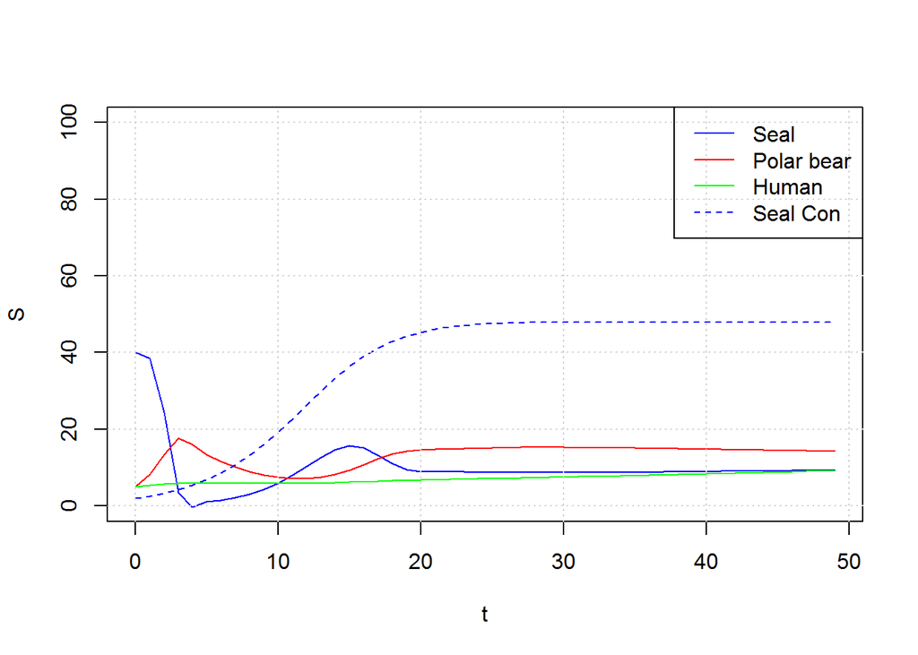

## Conclusion

Next I would try to find concrete proof that the system with human hunting is stable. By solving the jacobian and finding eigenvalues corresponding to jacobian. Once i figured out it is stable I would try to add other factors which could affect polar bear populations one example of this is increased shipping through the arctic ocean which is becoming a viable route of ships in the foreseeable future. Below is an example of modelling this.

# Another Extension

```r
S <- 1:50 #Seal population
P <- 1:50 #Polar bear population
H <- 1:50 #Human population
CS <- 1:50 #Seal conservation population
CP <- 1:50 #Polar bear conservation population
I <- 1:50 #Industrial shipping through northwest passage

S[1] = 40 #Initial Seal population
P[1] = 5 #Initial polar bear population
H[1] = 5 #Initial human population
CS[1] = 2 #Initial seal conservation population
CP[1] = 2 #Initial polar bear conservation population
I[1] = 1 #Initial amount of Industrial activity (shipping)

#Equation 1 seal population
rg <- 0.5 #Seal growth rate without polar bear or humans.
cps <- 0.1 #seal-polar bear encounter rate
is <- 0.1 #industrial effect on seal population
SC <- 100 #seal carrying capacity

#Equation 2 polar bear population
eps <- 0.2 #polar bear efficiency to convert one seal to another polar bear
dp <- 0.1 #polar bear mortality rate
ip <- 0.1 #industrial effect on polar bear population

#Equation 3 human population
ehs <- 0.01 #human efficiency to convert seals to human
ehp <- 0.01 #human efficiency to convert polar bears to human
chs <- 0.01 #seal human encounter rate
chp <- 0.01 #polar bear human encounter rate
dh <- 0.5 #human mortality rate
ih <- 0.05 #industrial effect on human population

#Equation 4
KSC <- 80 #Capacity
rs <- 1.1 #seal growth rate in conservation area
ms <- 0.9 #seal migration out rate

#Equation 5
KPC <- 30 #Capacity
rp <- 1.1 #polar growth rate in conservation area
mp <- 0.5 #polar bear migration out rate

#Equation 6
ri <- 0.10 #industrial shipping growth rate
EC <- 100 #Economic constraint represents diminishing returns of economic growth

for (t in 1:49) {
  #Seal population
  S[t + 1] <- S[t] + rg*S[t] - cps*S[t]*P[t] - chs*S[t]*H[t] - is*S[t]*I[t] + ms*CS[t]
  #Polar bear population
  P[t + 1] <- P[t] + eps*cps*S[t]*P[t] - dp*P[t] - chp*P[t]*H[t] - ip*P[t]*I[t] + mp*CP[t]
  #Human Population
  H[t+1] <- H[t] + ehs*chs*S[t]*H[t] + ehp*chp*P[t]*H[t] + ih*H[t]*I[t] - dh*H[t]
  #Seal Conservation
  CS[t+1] <- CS[t] + rs*CS[t]*(1 - CS[t]/KSC) - ms*CS[t]  #1 dimensional
  #Polar bear Conservation
  CP[t+1] <- CP[t] + rp*CP[t]*(1 - CP[t]/KPC) - mp*CP[t] #1 dimensional
  #Industial Shipping through Northwest Passage
  I[t+1] <- I[t] + ri*I[t]*(1 - I[t]/EC)
}
```

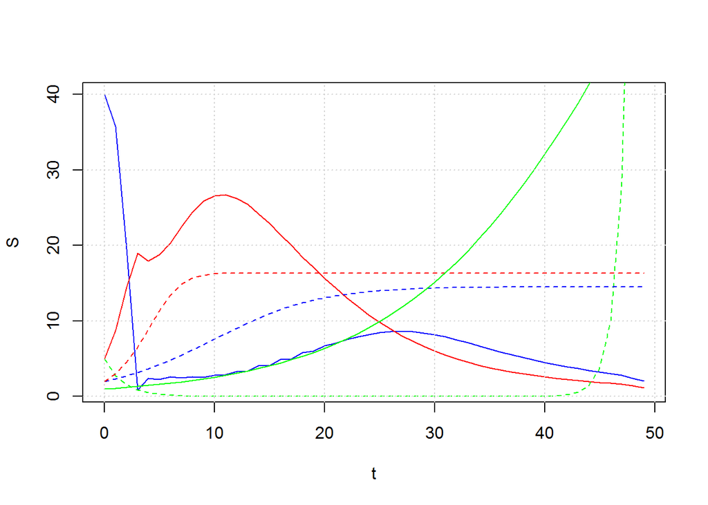

where:  
$r_{g}$ - Seal growth rate  
$c_{ps}$ - Polar bear seal interaction rate  
$c_{hs}$ - Human Seal interaction rate  
$i_{s}$ - Population decline resulting from increasing economic activity  
$e_{ps}$ - Polar bear efficiency to convert one seal to another polar bear  
$c_{ps}$ - Polar bear seal interaction rate  
$c_{hp}$ - Polar bear human interaction rate  
$d_{p}$ - Polar bear natural mortality rate  
$i_{p}$ - Population decline resulting from increasing economic activity  
$e_{hs}$ - Human efficiency to convery one seal to a human  
$e_{hp}$ - Human efficiency to convert one polar bear to a human  
$c_{hs}$ - Human seal interaction rate  
$c_{hp}$ - Human polar bear interaction rate  
$d_{h}$ - Human mortality rate  
$i_{h}$ - Population growth resulting from increasing economic activity  
$r_{S}$ - Seal reservation growth rate  
$m_S$ - Seal migration out rate  
$K_{SC}$ - Seal reserve capacity  
$r_{P}$ - Polar bear reservation growth rate  
$m_P$ - Polar bear migration out rate  
$K_{PC}$ - Polar bear reserve capacity  
$r_{i}$ - Industrial growth rate factors include melting of ice in northwest passage area  
$EC$ - Economic capacity represents diminishing returns in GDP growth  
**Refrences** 1. Mooney, Douglas. A Course in Mathematical Modeling. The Mathematical Association of America, Print. 2. [linked phrase](http://www.polarbearhabitat.ca/research)  
3. [WWF](http://www.wwf.ca/conservation/arctic/wildlife/polar_bear/)  
4. [Polar Bears International](http://www.polarbearsinternational.org/about-polar-bears/essentials/hunting-and-eating)  
5. [World Wild Life](http://www.worldwildlife.org/species/polar-bear)